# Biweekly-Checkin 3

# Jacob Tiede

## Image to Image Translation

### Defining the Problem

This week I'm hoping to get a better idea of how to leverage different losses to help a model learn. To this end, the new skill that I wanted to learn was image to image translation since I have heard that computer vision has some especially interesting takes on how to leverage loss to improve models. This is a method of taking an image and "translating" it into another image with a different style, but the same content. This could be taking an image of a location in the day and rewriting it at night or taking the outline of a handbag and translating it into the full colored-in handbag. For this I will be working with the somewhat well known pix2pix dataset in order to take satellite images and translate them to a map-like abstraction of the same content as the satellite image. The data can be found here: https://www.kaggle.com/vikramtiwari/pix2pix-dataset. I will also be following work on using Conditional Adversarial Networks to solve this type of problem found here:https://arxiv.org/pdf/1611.07004.pdf which I will now summarize.

### How to Solve this Problem

To start, let's consider a sub-problem in this field that we would like to solve with Adversarial Networks: the problem of expert knowledge. Expert knowledge has been required for asking the right questions in this domain for many years, and it was required to answer one of the most important questions of training convolutional neural nets: what loss function should we use? Adversarial Networks solve this problem by making the loss implicitly in terms of another neural network. This means that our loss is actually adapting to the data, and thus becomes better at generalizing. This paper, in fact, sets out to provide the most general structure possible for solving these problems, each of which we will discuss in turn. To start, I'll describe what a conditional GAN is in this context.

#### Aside: Conditional GANs

To understand the need for a new method consider the problem presented by using a non-conditional GAN (as I implemented in the first biweekly report) to solve this problem. In other words, how would we tell a non-conditional GAN to generate an output based off of a template? We can't, non-conditional GANs simply generate outputs that are similar to the training set, but they have no ability to distinguish between templates. For this, we will need to not only feed the generator a random vector from the latent space, we will also need to tell it the template that we want it in. This is accomplished by feeding the generator a random vector as well as one of the training "templates". In order to properly train the generator to output something with the proper template in mind we also need to provide the discriminator the template as an input. In this way a conditional GAN learns to pair an input with an output. This is exactly how our scheme will operate, but there is some subtlety in the construction of the net. To that end, let's talk about U-net:

#### Aside: U-Net

The best results from this paper are from the so-called U-net architecture. To better understand this setup I will summarize this blog post: https://towardsdatascience.com/unet-line-by-line-explanation-9b191c76baf5. At its core U-net consists of two paths each of which will be interconnected with one another. The first path (called the "contracting" path) will reduce the dimension of the input through blocks of the form: convolution -> convolution -> max pooling -> optional dropout. This will consistently reduce the dimension of the input by 1/2 for each block. The second path (called the "expansive" path) will have blocks of the form transposed convolution -> concatenate -> convolution -> convolution. The concatenation for this path provides the connections between the two paths. To understand where the connections are, recall that we will be concatenating along the channel dimension so the height and width of the data must be the same as both points in the contracting path and the expansive path. Now, imagine that we start with an image that is 20x20, after the first block in the contracting path the dimension will shrink to 10x10, then with the second it will shrink to 5x5. Then the first block in the expansive path will upsample the size to 10x10, allowing a "skip" connection to form between the output of the 2nd block in the contracting path and the output of the first block in the expansive path. In general this translates to a skip connection between the ith and n-ith layers of the model. This is how U-net works in general, and it has been found to be helpful for these kinds of tasks, because it has much better propagation of information throughout the model.

#### Losses

Moving back to the paper https://arxiv.org/pdf/1611.07004.pdf we have to discuss the losses that they use. The paper discusses the use of two loss functions: one for "high-frequency" correctness and one for "low-frequency" correctness. From what I can tell "low-frequency" correctness refers to the large features being correct (for instance a building is in the right place), but those features are not in high detail. "High-frequency" correctness is then the details being correct. The authors then state that low-frequency correctness can be attained through the use of simple L2 or L1 norms as applied to the output of the generator. In other words: $$ loss(G) = ||y - G(x, z)||_1 $$ Where $y$ is the ground truth image, $x$ is the template image that we feed into the conditional GAN, $z$ is the noise input, and $G$ is the generator. This will give us robust macro-level features, but how do we get the details right? For that we will need the discriminator's help. To this end the authors use the loss defined in the original paper on GANs: $$ loss(D,G) = log(D(y)) + log(1-D(G(x,y))) $$ Where $D$ is the discriminator. Now, this paper was published just before Wasserstein GANs were first introduced, so I'd like to try implementing Wasserstein loss as well: $$ loss(D,G) = -(D(x)-D(G(z))) - D(G(z)) $$ Of course, we can split this loss into separate optimization steps for the critic and generator as I did in the first bi-weekly report, but to stick with the notation in the paper I will keep it as a single loss. This then means that we have a complete loss as: $$ loss_{total}=loss(D,G)+\lambda loss(G) $$ Where $\lambda$ is just some constant that we set. By minimizing both of these objectives we can see that we should get both high and low-frequency correctness. However, there are some details for getting the discriminator to penalize only high-frequency structure. To make this robust the authors propose "PatchGAN". Rather than looking at the whole image, PatchGAN will take small NxN windows of the image and try to classify whether or not that NxN slice is real or fake. After taking patches across the whole picture we will average the responses to get the final output of $D$. This means that $D$ is less concerned with the overall structure of the picture, and more with the style within the picture. This requires some explanation since it is not exactly the same as anything we've done before.

The most important part of this section to remember, from my perspective, is this subtle tweak they do to the loss. They sort of decompose the problem of image reconstruction into two parts, getting the large features right and getting the details correct, and have two different losses, one to solve each of these subproblems.

#### Implementation:

We now have enough information to begin to implement this model. First we will read the data into python (using https://machinelearningmastery.com/how-to-implement-pix2pix-gan-models-from-scratch-with-keras/ if I got stuck):

```python
import torch
import torch.nn as nn
import torch.nn.functional as F
import pandas as pd
import numpy as np
import time
from sklearn.metrics import accuracy_score
import matplotlib.pyplot as plt
from PIL import Image
import torchvision.transforms.functional as TF
import os
import matplotlib.pyplot as plt
import progressbar #If you're missing this library it is found here: https://pypi.org/project/progressbar2/
print("Is a GPU available? ")
torch.cuda.is_available()
```

```
Is a GPU available?
```

```
True
```

```
100% (1096 of 1096) |####################| Elapsed Time: 0:00:23 Time:  0:00:23
```

```
The shape of the training data is: torch.Size([1096, 3, 600, 1200])
An example image:
```

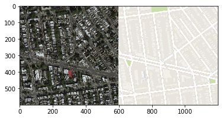

```python
#Load the data into python:

#The data is all in separate files, so we will need a way of reading a single jpg, appending it to our running tensor of data, and
#then reading another file
def loadData(folderName):
    #i keeps track of what image we are loading in (what row of our data we are currently loading)
    i = 0
    #For more info on how to use progress bar: https://pypi.org/project/progressbar2/
    numImages = len([name for name in os.listdir(folderName)])
    with progressbar.ProgressBar(max_value=numImages) as bar:
        #iterate through each file in a directory, code adapted from:
        #https://stackoverflow.com/questions/10377998/how-can-i-iterate-over-files-in-a-given-directory
        for file in os.listdir(folderName):
            if file.endswith(".jpg"):
                #read an image into pytorch: https://discuss.pytorch.org/t/how-to-read-just-one-pic/17434/2
                image = Image.open(os.path.join(folderName, file))
                x = TF.to_tensor(image)
                x.unsqueeze_(0)
                if i == 0:
                    out = torch.zeros(numImages, x.shape[1], x.shape[2], x.shape[3])
                    out[i,:,:,:] = x
                    i+=1
                else:
                    out[i,:,:,:] = x
                    i+=1
                bar.update(i)
    return out
trainData = loadData("./Data/maps/train")
print("The shape of the training data is: " + str(trainData.shape))

#Using showImage functions from my previous biweekly reports
def showImage(x):
    img = x.detach().cpu().numpy()
    plt.imshow(np.transpose(img, (1,2,0)), interpolation='nearest')
print("An example image:")
showImage(trainData[0,:,:,:])
```

You can see that each image is actually both the input image and the expected output, so let's write a function that separates these two:

```python
def splitData(x):
    train_x = x[:,:,:,0:int(np.floor(x.shape[3]/2))]
    train_y = x[:,:,:,int(np.ceil(x.shape[3]/2)):int(x.shape[3])]
    return train_x, train_y
train_x,train_y = splitData(trainData)
```

```
example of training data:
Shape: torch.Size([1096, 3, 600, 600])
```

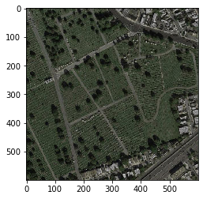

```python
print("example of training data: ")
print("Shape: " + str(train_x.shape))
showImage(train_x[5,:,:,:])
```

```
example of training target:
Shape: torch.Size([1096, 3, 600, 600])
```

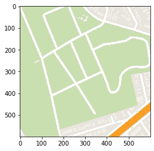

```python
print("example of training target: ")
print("Shape: " + str(train_y.shape))
showImage(train_y[5,:,:,:])
```

```python
#it is advantageous for our images to be a power of two since the generator will be down sampling by a factor of 2, we can simple crop the images so they are
#512x512
def cropData(x):
    output = torch.zeros(x.shape[0], x.shape[1], 512, 512)
    for i in range(x.shape[0]):
        output[i,:,:,:] = x[i,:,0:512,0:512]
    return output
train_x = cropData(train_x)
train_y = cropData(train_y)
```

```
example of training data:
Shape: torch.Size([1096, 3, 512, 512])
```

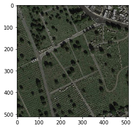

```python
print("example of training data: ")
print("Shape: " + str(train_x.shape))
showImage(train_x[5,:,:,:])
```

```
example of training target:
Shape: torch.Size([1096, 3, 512, 512])
```

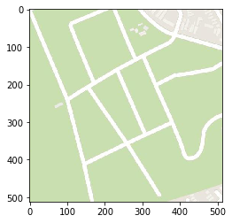

```python
print("example of training target: ")
print("Shape: " + str(train_y.shape))
showImage(train_y[5,:,:,:])
```

### EDA

I've been trying to get better about EDA and looking at my source code so-to-speak of my machine learning, so to this end I will try to do some EDA on these images. Using this forum post as a guide: https://datascience.stackexchange.com/questions/29223/exploratory-data-analysis-with-image-datset I will do some image EDA. First I'm curious to see the average image for each set to get an idea of what colors are present at pixel locations on average:

```
Mean input image:
```

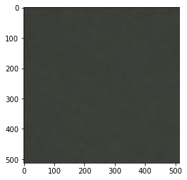

```python
def getAvgIm(x):
    return torch.mean(x, dim = 0)
print("Mean input image: ")
showImage(getAvgIm(train_x))
```

```
average ground truth image
```

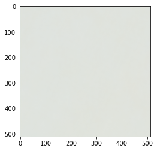

```python
print("average ground truth image")
showImage(getAvgIm(train_y))
```

Since each of these images are just a single color (which appears to be the background color of a normal image) we can say that there aren't really any over represented patterns in the images (or else we would see some sort of pattern to the image, like the ghost of a road that exists in most images). This means that road placement, the existence of trees, or highway placement is approximately random, which is good since it means our model will have to actually learn to look at the template rather than learning some average pattern. Now, why don't we look at a histogram of the average values, since some images may have more green and some may have more blue, etc:

```
Histogram of Colors in the Template Images:
```

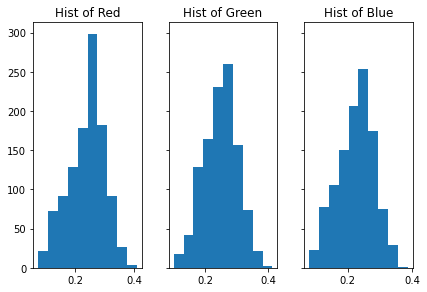

```python
def colorHist(x):
    #keep track of average values for RGB channels
    R = []
    G = []
    B = []
    for i in range(3):
        temp = []
        for j in range(x.shape[0]):
            temp.append(torch.mean(x[j,i,:,:]))
        if i == 0:
            R = np.array(temp)
        elif i == 1:
            G = np.array(temp)
        else:
            B = np.array(temp)
    fig, (ax1, ax2, ax3) = plt.subplots(1, 3,sharey=True)
    fig.tight_layout()

    ax1.hist(R)
    ax1.set_title("Hist of Red")
    ax2.hist(G)
    ax2.set_title("Hist of Green")
    ax3.hist(B)
    ax3.set_title("Hist of Blue")
    #fig.show()
print("Histogram of Colors in the Template Images:")
colorHist(train_x)
```

```
Histogram of Colors in the Ground Truth Images:
```

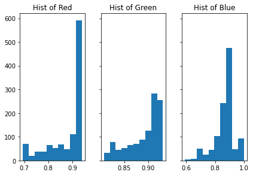

```python
print("Histogram of Colors in the Ground Truth Images:")
colorHist(train_y)
```

Interestingly, it looks like the average intensity values of all of the color channels increases when we translate the image from a satellite image to an abstracted google maps image. We also see that the translated images seem to have less variance in their colors when compared to the satellite (template) images. This distributional difference will hopefully not prove to be a challenge for the GAN, but in case we get less than optimal results one thing to try would be normalizing each image. This analysis also shows us that there aren't really any extremely strange images, nor does it appear that there are any images that do not belong in the dataset (which, if there were images that shouldn't have been there, we would most likely see an outlier on one of the color channels). The last thing to confirm before we begin working with the images is that our data is within the range that we expect (-1 to 1):

```python
print("The range of the satellight images is: " + str(torch.min(train_x)) + " to " + str(torch.max(train_x)))
print("The range of the Google Maps images is: " + str(torch.min(train_y)) + " to " + str(torch.max(train_y)))
```

```
The range of the satellight images is: tensor(0.) to tensor(1.)
The range of the Google Maps images is: tensor(0.) to tensor(1.)
```

This is somewhat strange, but not something that we cannot handle. Our Generator neural net (as implemented by the paper) will have a tanh activation function which has a range of (-1 to 1), but if the generator ever outputs a pixel of less than 0 the discriminator could easily determine if it was real or fake (given an ideal strategy). This presents us with two options: we could either substitute the tanh activation for a sigmoid, or we can rescale the image. I will opt for the former since it should be a simple change. Now, we can implement our model:

#### Structure of the Generator

For this section we will be referring to the appendix of the paper. To start, we will consider the generator's architecture which will be built from blocks of convolution -> batch norm -> ReLU layers denoted by $Ck$ where $k$ is the number of output filters. Each of these blocks will be assumed to have 4x4 kernels with a stride of 2. In the encoder, these blocks will reduce the dimension of the input by 1/2, and in the decoder we will be using transposed convolutions in place of the convolution block, so it will increase the dimension by a factor of 2. As a note, the paper uses some dropout, and layers with dropout are denoted by $CDk$, the most interesting aspect of these blocks are that they are how the model encodes noise from the latent space for modeling purposes. These blocks will look like this:

Encoder: C64 -> C128 -> C256 -> C512 -> C512 -> C512 -> C512 -> C512  
Decoder: CD512 -> CD1024 -> CD1024 -> C1024 -> C1024 -> C512 -> C256 -> C128 (remember that in this section the convolution layers are replaced by transposed convolutions)

```
Generator's first attempt at generating an image:
```

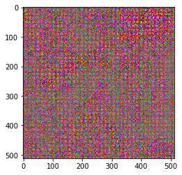

```python
"""
encoderBlock - defines a single encoder block for the generator

@params: Cin - int, the number of input channels
         Cout - int, the number of output channels
         batchNorm - bool, tells us if we should use batch normalization for this layer or not
@methods: forward: defines the forward pass of the model
"""
class encoderBlock(nn.Module):
    def __init__(self, Cin, Cout, batchNorm = True):
        super(encoderBlock, self).__init__()
        self.conv = nn.Conv2d(Cin, Cout, 4, stride = 2, padding = 1)
        self.BN = nn.BatchNorm2d(Cout)
        self.leReLU = nn.LeakyReLU(.2)
        self.batchNorm = batchNorm
    def forward(self, x):
        if self.batchNorm:
            x = self.leReLU(self.BN(self.conv(x)))
        else:
            x = self.leReLU(self.conv(x))
        return x

"""
decoderBlock - defines a decoder block for the generator

@params: Cin - int, the number of input channels
         Cout - int, the number of output channels
         useDrop - bool, whether or not to use a dropout layer
         batchNorm - bool, whether or not to use batch normalization
@methods: forward(self, x): defines the forward pass of the model
"""
class decoderBlock(nn.Module):
    def __init__(self, Cin, Cout, useDrop = True, batchNorm = True):
        super(decoderBlock, self).__init__()
        self.tConv = nn.ConvTranspose2d(Cin, Cout, 4, stride = 2, padding = 1)
        self.BN = nn.BatchNorm2d(Cout)
        self.drop = nn.Dropout(.5)
        self.useDrop = useDrop
        self.batchNorm = batchNorm
    def forward(self, x):
        if self.useDrop and self.batchNorm:
            x = self.drop(self.BN(self.tConv(x)))
        elif self.batchNorm:
            x = self.BN(self.tConv(x))
        else:
            x = self.tConv(x)
        return x

"""
Generator - defines a generator for our image translations task, expects images to be 512x512

@params - None
@methods: forward(self, x): Defines the forward pass of the model
"""
class Generator(nn.Module):
    def __init__(self):
        super(Generator, self).__init__()
        #define our encoder blocks:
        #512x512
        self.enc1 = encoderBlock(3, 64, False)
        #256x256
        self.enc2 = encoderBlock(64, 128)
        #128x128
        self.enc3 = encoderBlock(128, 256)
        #64x64
        self.enc4 = encoderBlock(256, 512)
        #32x32
        self.enc5 = encoderBlock(512, 512)
        #16x16
        #this is probably small enough to start adding decoder blocks (I was not able to make the full model due to RAM issues)
        self.dec1 = decoderBlock(512,512)
        #32x32
        self.dec2 = decoderBlock(512*2, 256)
        #64x64
        self.dec3 = decoderBlock(512, 128)
        #128x128
        self.dec4 = decoderBlock(256, 64, False)
        #256x256
        self.dec5 = decoderBlock(128, 3, False, False)
        #512x512
    def forward(self, x):
        #list of the inputs to use in U-net
        temp = []
        x = self.enc1(x)
        #append for use in U-net
        temp.append(x)
        x = self.enc2(x)
        temp.append(x)
        x = self.enc3(x)
        temp.append(x)
        x = self.enc4(x)
        temp.append(x)
        x = self.enc5(x)

        x = self.dec1(x)
        x = F.relu(torch.cat((x, temp[3]), dim = 1))
        x = self.dec2(x)
        x = F.relu(torch.cat((x, temp[2]), dim = 1))
        x = self.dec3(x)
        x = F.relu(torch.cat((x, temp[1]), dim = 1))
        x = self.dec4(x)
        x = F.relu(torch.cat((x, temp[0]), dim = 1))

        x = torch.sigmoid(self.dec5(x))
        return x
generator = Generator()
print("Generator's first attempt at generating an image:")
showImage(generator(train_x[5,:,:,:].view(1,3,512,512))[0,:,:,:])
```

To U-net's credit you can sort of see that some of the macro-structure of the image (the little blocks that you can sort of see throughout the image) has been retained throughout the net, which is probably one of the reasons why this network is so effective.

#### Structure of the Curator:

Using the same notation as for the generator, the curator can be written as:

C64-C128-C256-C512

Again, with no batch norm applied to the first layer, and all of the ReLUs as leaky ReLUs with slope .2. After applying all of these layers a final convolution is applied to make the dimension have a single channel. First we'll implement this model using the loss from the paper, then we will observe how our results change when we use Wasserstein loss. Implementing this gives:

```python
"""
Curator - define a discriminator for image to image translation

@params - None
@methods: forward(self, x): define the forward pass of the model
"""
class Curator(nn.Module):
    def __init__(self):
        super(Curator, self).__init__()
        self.C64 = encoderBlock(6, 64, False)
        self.C128 = encoderBlock(64, 128)
        self.C256 = encoderBlock(128,256)
        self.C512 = encoderBlock(256, 512)

        self.conv1 = nn.Conv2d(512, 1, 4, padding = 2)
    def forward(self, x):
        x = self.C64(x)
        x = self.C128(x)
        x = self.C256(x)
        x = self.C512(x)
        x = torch.sigmoid(self.conv1(x))
        return x
```

#### Training

Using the loss from the paper:

```python
#Get samples from "data", temp is a list of random integers of size batch_size
def getRealSamples(data, temp):
    result = data[temp, :, :, :]
    return result
critic = Curator().cuda()
gen = Generator().cuda()

#define our two optimizers
learning_rate = .01

gOptimizer = torch.optim.Adam(gen.parameters(), lr=learning_rate)
dOptimizer = torch.optim.Adam(critic.parameters(), lr=learning_rate)

#Recall that half of the loss is the L1/L2 norm, we will use L1
loss = nn.L1Loss()

#Now we will define the training loop:
epochs = 10
batch_size = 4
batchesPerEpoch = int(np.floor(train_x.shape[0]/batch_size))
#Note: this code was adapted from my first biweekly report
with progressbar.ProgressBar(max_value=epochs*batchesPerEpoch) as bar:
    for epoch in range(epochs):
        running_gen_loss = 0
        for i in range(batchesPerEpoch):
            epsilon = 10**-6
            #set the gradients of the critic to zero
            dOptimizer.zero_grad()
            #get a minibatch of the real data with their corresponding templates
            temp = torch.randint(low=0, high = int(train_x.shape[0]), size = (batch_size,))
            genMiniBatch_x = getRealSamples(train_x, temp).cuda()
            genMiniBatch_y = getRealSamples(train_y, temp).cuda()
            #Start by training the discriminator
            #Get Dx, the discriminator when applied to the minibatch of real data
            #Note: these are concatinated channel-wise to give both the template and the generated/real image to the discriminator
            realMiniBatch = torch.cat((genMiniBatch_x, genMiniBatch_y), dim = 1)
            #take the mean here since we will get a set of predictions for each patch in our image (see patchGAN explanation)
            Dx = torch.mean(critic(realMiniBatch))
            #calculate the loss associated with this step
            dxLoss = -1*torch.mean(torch.log(Dx+epsilon))
            #find the gradients for this step
            dxLoss.backward()


            #generate fake images
            Gz = gen(genMiniBatch_x.float())
            #apply the discriminator to fake images concatinated with the template
            critInput = torch.cat((genMiniBatch_y, Gz), dim = 1)
            DGz = torch.mean(critic(critInput))
            #Find the loss associated with this step
            dgzLoss = 1*torch.mean(torch.log(1-DGz+epsilon))
            #Accumulate the gradients for this half of the loss
            dgzLoss.backward()
            #set the total loss as the sum of our two previous losses
            dLoss = dgzLoss+dxLoss
            dOptimizer.step()



            #set the generator's gradients to zero
            gOptimizer.zero_grad()
            temp = torch.randint(low=0, high = int(train_x.shape[0]), size = (batch_size,))
            genMiniBatch_x = getRealSamples(train_x, temp).cuda()
            genMiniBatch_y = getRealSamples(train_y, temp).cuda()
            Gz = gen(genMiniBatch_x.float())
            #apply the discriminator to the generated images
            critInput = torch.cat((genMiniBatch_y, Gz), dim = 1)
            DGz = torch.mean(critic(critInput))
            #Calculate this again so pytorch doesn't get confused in backprop
            Gzl1 = gen(genMiniBatch_x.float())
            #calculate the loss
            gLoss = -1*torch.mean(torch.log(DGz+epsilon)) + loss(Gzl1, genMiniBatch_y)
            #accumulate the gradients
            gLoss.backward()
            gOptimizer.step()
            bar.update(i+batchesPerEpoch*epoch)

print("Done traininig")
```

```
100% (2740 of 2740) |####################| Elapsed Time: 0:34:49 Time:  0:34:49
```

```
Done traininig
```

```
Template given:
```

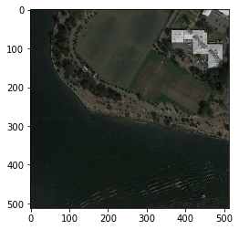

```python
#lets print some of the images
temp = torch.randint(low=0, high = int(train_x.shape[0]), size = (batch_size,))
genMiniBatch_x = getRealSamples(train_x, temp).cuda()
genMiniBatch_y = getRealSamples(train_y, temp).cuda()
Gz = gen(genMiniBatch_x.float())
print("Template given:")
showImage(genMiniBatch_x[0,:,:,:])
```

```
Ground Truth:
```

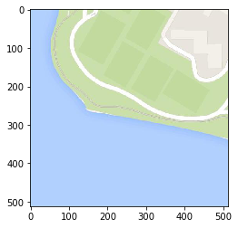

```python
print("Ground Truth:")
showImage(genMiniBatch_y[0,:,:,:])
```

```
Generated image:
```

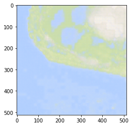

```python
print("Generated image:")
showImage(Gz[0,:,:,:])
```

This worked great! It's still blurry (probably a result of my not training it very long), but you can see that its output is quite detailed. You can see that it has interpreted part of the image as water, which it has incorporated into the image, so even though it wasn't supposed to put water in the image it does act as a testament to the level of detail that this GAN can see. As we'll soon see (when I separate each loss), this level of detail is not seen when using just the L1 loss, nor is this macrostructure seen when just using the GAN loss. Now we can try using Wasserstein loss:

```python
#Need to slightly change the curator
class Curator(nn.Module):
    def __init__(self):
        super(Curator, self).__init__()
        self.C64 = encoderBlock(6, 64, False)
        self.C128 = encoderBlock(64, 128)
        self.C256 = encoderBlock(128,256)
        self.C512 = encoderBlock(256, 512)

        self.conv1 = nn.Conv2d(512, 1, 4, padding = 2)
    def forward(self, x):
        x = self.C64(x)
        x = self.C128(x)
        x = self.C256(x)
        x = self.C512(x)
        x = self.conv1(x)
        return x
```

```python
critic = Curator().cuda()
gen = Generator().cuda()
#define our two optimizers
learning_rate = .001
#Use two separate RMSProp optimizers, one for the generator and one for the discriminator
gOptimizer = torch.optim.RMSprop(gen.parameters(), lr=learning_rate)
dOptimizer = torch.optim.RMSprop(critic.parameters(), lr=learning_rate)
loss = nn.L1Loss()
#Now we will define the training loop:
epochs = 10
batch_size = 4
batchesPerEpoch = int(np.floor(train_x.shape[0]/batch_size))
#code adapted from my first biweekly report
with progressbar.ProgressBar(max_value=epochs*batchesPerEpoch) as bar:
    for epoch in range(epochs):
        running_gen_loss = 0
        for i in range(batchesPerEpoch):
            #number of extra times that we will train the critic
            start = time.time()
            criticConst = 5
            for j in range(criticConst):
                #set the gradients of the critic to zero
                dOptimizer.zero_grad()
                #get a minibatch of the real data
                temp = torch.randint(low=0, high = int(train_x.shape[0]), size = (batch_size,))
                genMiniBatch_x = getRealSamples(train_x, temp).cuda()
                genMiniBatch_y = getRealSamples(train_y, temp).cuda()
                #Start by training the discriminator
                #Get Dx, the discriminator when applied to the minibatch of real data
                realMiniBatch = torch.cat((genMiniBatch_x, genMiniBatch_y), dim = 1)
                Dx = torch.mean(critic(realMiniBatch))
                #calculate the loss associated with this step
                dxLoss = -1*torch.mean(Dx)
                #find the gradients for this step
                dxLoss.backward()
                #generate fake images
                Gz = gen(genMiniBatch_x.float())
                #apply the discriminator to fake images concatinated with the template
                critInput = torch.cat((genMiniBatch_y, Gz), dim = 1)
                DGz = torch.mean(critic(critInput))
                #Find the loss associated with this step
                dgzLoss = 1*torch.mean(DGz)
                #Accumulate the gradients for this half of the loss
                dgzLoss.backward()
                #set the total loss as the sum of our two previous losses
                dLoss = dgzLoss+dxLoss
                dOptimizer.step()
                #weight clipping
                for j in critic.parameters():
                    j.data.clamp_(-.1,.1)


            #set the generator's gradients to zero
            gOptimizer.zero_grad()
            temp = torch.randint(low=0, high = int(train_x.shape[0]), size = (batch_size,))
            genMiniBatch_x = getRealSamples(train_x, temp).cuda()
            genMiniBatch_y = getRealSamples(train_y, temp).cuda()
            #use the generator to make a new batch of images (even though we have already computed this we need to recompute it for pytorch to understand
            #how to backpropogate)
            Gz = gen(genMiniBatch_x.float())
            #apply the discriminator to the generated images
            critInput = torch.cat((genMiniBatch_y, Gz), dim = 1)
            DGz = torch.mean(critic(critInput))

            Gzl1 = gen(genMiniBatch_x.float())
            #calculate the loss
            gLoss = -1*torch.mean(DGz) + loss(Gzl1, genMiniBatch_y)
            #accumulate the gradients
            gLoss.backward()
            gOptimizer.step()
            bar.update(i+batchesPerEpoch*epoch)

print("Done traininig")
```

```
100% (2740 of 2740) |####################| Elapsed Time: 1:36:01 Time:  1:36:01
```

```
Done traininig
```

```
Template given:
```

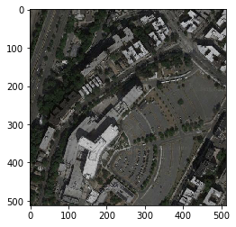

```python
#lets print some of the images
temp = torch.randint(low=0, high = int(train_x.shape[0]), size = (batch_size,))
genMiniBatch_x = getRealSamples(train_x, temp).cuda()
genMiniBatch_y = getRealSamples(train_y, temp).cuda()
Gz = gen(genMiniBatch_x.float())
print("Template given:")
showImage(genMiniBatch_x[0,:,:,:])
```

```
Ground Truth:
```

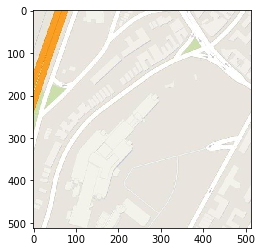

```python
print("Ground Truth:")
showImage(genMiniBatch_y[0,:,:,:])
```

```
Generated image:
```

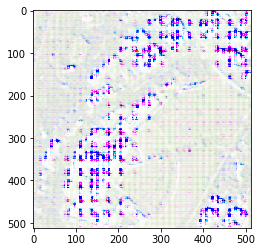

```python
print("Generated image:")
showImage(Gz[0,:,:,:])
```

Interestingly, it looks like Wasserstein loss actually produces worse results. This probably has to do with how patch GAN works rather than the loss itself. Because our loss is unconstrained in Wasserstein GANs, and because in patch GANs we are finding a score for regions in sections of the visual field, we can see that the GAN doesn't actually need to learn details everywhere, it just needs to really convince one section of discriminator that it is real, then it can ignore the rest. This is because if one section of the curator is fooled it might give a value of 100000 for that area, which when combined with the rest of the visual fields could completely skew the results (especially since we are also using L1 loss to get a corrected macrostructure of the model, so every part of the image should at least be somewhat close to what a real google maps image would look like).

#### Showing that the Loss Functions Split this Problem into Multiple Parts

To convince myself that using two loss functions added together really do (mostly) separate things I will train the generator on just the GAN loss and see if it produces worse results. Since this Wasserstein loss didn't work out I'll go back to using the other loss:

```python
class Curator(nn.Module):
    def __init__(self):
        super(Curator, self).__init__()
        self.C64 = encoderBlock(6, 64, False)
        self.C128 = encoderBlock(64, 128)
        self.C256 = encoderBlock(128,256)
        self.C512 = encoderBlock(256, 512)

        self.conv1 = nn.Conv2d(512, 1, 4, padding = 2)
    def forward(self, x):
        x = self.C64(x)
        x = self.C128(x)
        x = self.C256(x)
        x = self.C512(x)
        x = torch.sigmoid(self.conv1(x))
        return x

critic = Curator().cuda()
gen = Generator().cuda()
#define our two optimizers
learning_rate = .01

gOptimizer = torch.optim.Adam(gen.parameters(), lr=learning_rate)
dOptimizer = torch.optim.Adam(critic.parameters(), lr=learning_rate)
loss = nn.L1Loss()
#Now we will define the training loop:
epochs = 10
batch_size = 4
batchesPerEpoch = int(np.floor(train_x.shape[0]/batch_size))
#removed comments since this training loop is largely the same as above
with progressbar.ProgressBar(max_value=epochs*batchesPerEpoch) as bar:
    for epoch in range(epochs):
        running_gen_loss = 0
        for i in range(batchesPerEpoch):
            epsilon = 10**-6
            dOptimizer.zero_grad()
            temp = torch.randint(low=0, high = int(train_x.shape[0]), size = (batch_size,))
            genMiniBatch_x = getRealSamples(train_x, temp).cuda()
            genMiniBatch_y = getRealSamples(train_y, temp).cuda()
            realMiniBatch = torch.cat((genMiniBatch_x, genMiniBatch_y), dim = 1)
            Dx = torch.mean(critic(realMiniBatch))
            dxLoss = -1*torch.mean(torch.log(Dx+epsilon))
            dxLoss.backward()
            Gz = gen(genMiniBatch_x.float())
            critInput = torch.cat((genMiniBatch_y, Gz), dim = 1)
            DGz = torch.mean(critic(critInput))
            dgzLoss = 1*torch.mean(torch.log(1-DGz+epsilon))
            dgzLoss.backward()
            dLoss = dgzLoss+dxLoss
            dOptimizer.step()


            gOptimizer.zero_grad()
            temp = torch.randint(low=0, high = int(train_x.shape[0]), size = (batch_size,))
            genMiniBatch_x = getRealSamples(train_x, temp).cuda()
            genMiniBatch_y = getRealSamples(train_y, temp).cuda()
            Gz = gen(genMiniBatch_x.float())
            critInput = torch.cat((genMiniBatch_y, Gz), dim = 1)
            DGz = torch.mean(critic(critInput))

            Gzl1 = gen(genMiniBatch_x.float())
            gLoss = -1*torch.mean(torch.log(DGz+epsilon))
            gLoss.backward()
            gOptimizer.step()
            bar.update(i+batchesPerEpoch*epoch)

print("Done traininig")
```

```
100% (2740 of 2740) |####################| Elapsed Time: 0:29:26 Time:  0:29:26
```

```
Done traininig
```

```
Template given:
```

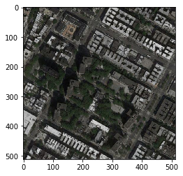

```python
#lets print some of the images
temp = torch.randint(low=0, high = int(train_x.shape[0]), size = (batch_size,))
genMiniBatch_x = getRealSamples(train_x, temp).cuda()
genMiniBatch_y = getRealSamples(train_y, temp).cuda()
Gz = gen(genMiniBatch_x.float())
print("Template given:")
showImage(genMiniBatch_x[0,:,:,:])
```

```
Ground Truth:
```

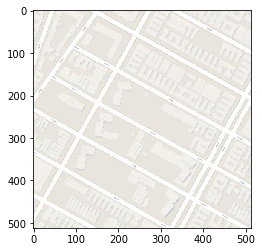

```python
print("Ground Truth:")
showImage(genMiniBatch_y[0,:,:,:])
```

```
Generated image:
```

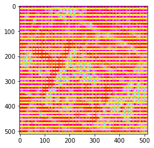

```python
print("Generated image:")
showImage(Gz[0,:,:,:])
```

This is very interesting, because you can see some structure to this, but without the ability to learn any macrostructures it is impossible for it to learn anything about what it should output (at least in a reasonable time frame, maybe more training would help, but without a faster computer this may not be feasible). Now, let's use just the L1 loss:

```python
gen = Generator().cuda()
#define our two optimizers
learning_rate = .01
#Use two separate RMSProp optimizers, one for the generator and one for the discriminator
gOptimizer = torch.optim.Adam(gen.parameters(), lr=learning_rate)
loss = nn.L1Loss()
#Now we will define the training loop:
epochs = 10
batch_size = 4
batchesPerEpoch = int(np.floor(train_x.shape[0]/batch_size))
with progressbar.ProgressBar(max_value=epochs*batchesPerEpoch) as bar:
    for epoch in range(epochs):
        running_gen_loss = 0
        for i in range(batchesPerEpoch):
            #set the generator's gradients to zero
            gOptimizer.zero_grad()
            temp = torch.randint(low=0, high = int(train_x.shape[0]), size = (batch_size,))
            genMiniBatch_x = getRealSamples(train_x, temp).cuda()
            genMiniBatch_y = getRealSamples(train_y, temp).cuda()
            #use the generator to make a new batch of images (even though we have already computed this we need to recompute it for pytorch to understand
            #how to backpropogate)
            Gz = gen(genMiniBatch_x.float())
            #apply the discriminator to the generated images
            critInput = torch.cat((genMiniBatch_y, Gz), dim = 1)
            DGz = torch.mean(critic(critInput))

            Gzl1 = gen(genMiniBatch_x.float())
            #calculate the loss
            gLoss = loss(Gzl1, genMiniBatch_y)
            #accumulate the gradients
            gLoss.backward()
            gOptimizer.step()
            bar.update(i+batchesPerEpoch*epoch)

print("Done traininig")
```

```
100% (2740 of 2740) |####################| Elapsed Time: 0:13:08 Time:  0:13:08
```

```
Done traininig
```

```
Template given:
```

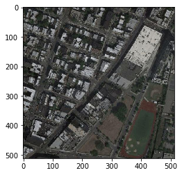

```python
#lets print some of the images
temp = torch.randint(low=0, high = int(train_x.shape[0]), size = (batch_size,))
genMiniBatch_x = getRealSamples(train_x, temp).cuda()
genMiniBatch_y = getRealSamples(train_y, temp).cuda()
Gz = gen(genMiniBatch_x.float())
print("Template given:")
showImage(genMiniBatch_x[0,:,:,:])
```

```
Ground Truth:
```

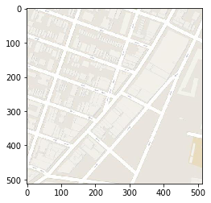

```python
print("Ground Truth:")
showImage(genMiniBatch_y[0,:,:,:])
```

```
Generated image:
```

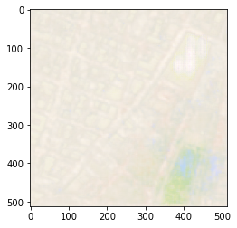

```python
print("Generated image:")
showImage(Gz[0,:,:,:])
```

So, you can definitly see that all of the macro structure is there, it just looks blurrier than the image generated when we use both losses. From these two experiments I think I can conclude that this indeed separates the task of generating images into two distinct tasks, which is very useful.

#### Final Thoughts

This was a super cool project, not just to see conditional GANs in action, but also to see how loss can be adjusted to acheive different goals. I would like to apply some of these ideas to my final project for this class, but I'll mention that in the README.md of this biweekly report.